# Metrics of Aging - Phenotypic Aging in BLSA

Perry Kuo, Luigi Ferrucci, Jennifer Schrack, Michelle Shardell, Morgan Levine

14 December 2018

The format is adopted from course led by [Dr. Stephanie Hicks](https://jhu-advdatasci.github.io/2018/)

# Motivation

With the advent of public health and medical care, the life expetancy has increased over past half century. The society is aging, and there are more and more researchers trying to understand the underlying mechanism why human age, and the potential modifiable facorts to decelerate the aging process. To achieve these goals, some researchers proposed some metrics to capture the functional aging, such as frailty index, and further investigate the relationship between functional aging and disability/mortality. With the hypothesis that functions are especially important for older people and applying potential approaches to improve functions may maximize human’s quality of life and prolong longevity, functional aging has been one of the main foci in geriatric research over past two decades. Consequently, it is of vital importance to understand the drivers of functional declines, which can be potentially measured by changes of phenotypes.

To understand the biological mechanism of aging, several metrics of biological age, such as epigenetic clock, have been proposed. Among these proposed metrics, most of them utilized the data available, and leverage on the dimension reduction tools and choose the statitical model fit the mortality the best as biological age. With lack of a more conceptual and mechanistic framework, these metrics may be useful for mortality or cormorbitidy prediction, but may not be able to capture the earlier change of aging.

Thus, we propose a temporal heirarchy framework for metrics of aging, in which phenotypes serve as the bridge between underlying biological drivers of aging and the functional decline we observe. Earlier this year, the concept has been described by [Dr. Luigi Ferrucci et al](https://www.ahajournals.org/doi/10.1161/CIRCRESAHA.118.312816), and is shown as following:

[figure not shown]

with proposed measures as following:

[figure not shown]

With an attempt to understand these temporal heirarchy of aging, in Baltimore Loungitudinal Study of Aging (BLSA), not only the functions, but also the proposed phenotypes were measured within participants with relatively health status when recruited, for the purpose of diminishing the effect of diseases as more as possible.

In this paper, we try to understand:

*1. Are the proposed phenotypes appropriate in terms of functional decline?*  
*2. Do the proposed phenotyes within the same domain capture similar properties? And do the prosposed phenotyeps accross different domians capture the construct of aging?*

# Are the proposed phenotypes appropriate?

This is the other way to visualize our conceptual domains, with proposed variables.

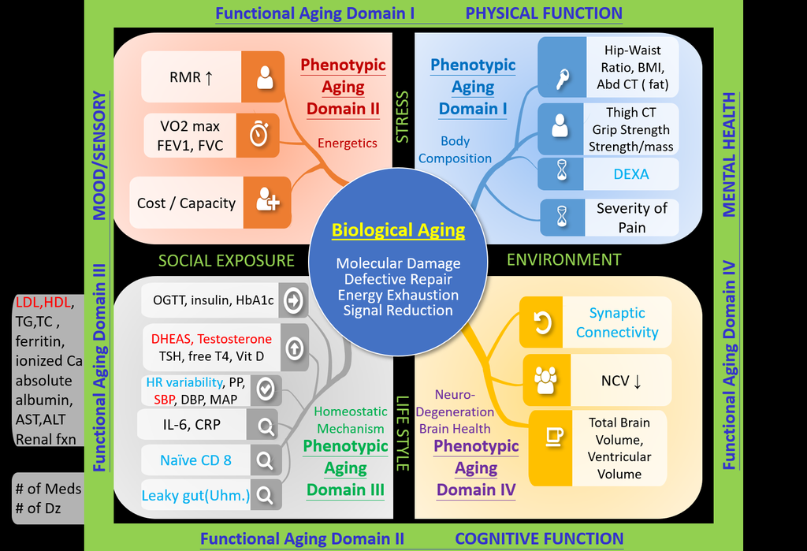

The proposed measures have been earlier described in one paper published on [Circulatoin Research](https://www.ahajournals.org/doi/10.1161/CIRCRESAHA.118.312816).

These include: * Energetics * Body composition * Homeostaic mechanism * Brain health

## Energetics

These include: * Resting metabolic rate  
* Cost-capacity ratio  
* VO2_max (treadmill)  
* Peak VO2(during 400m walk)  
* FEV1  
* FVC  
* FEV1/FVC

### Resting metabolic rate

#### Baseline distribution

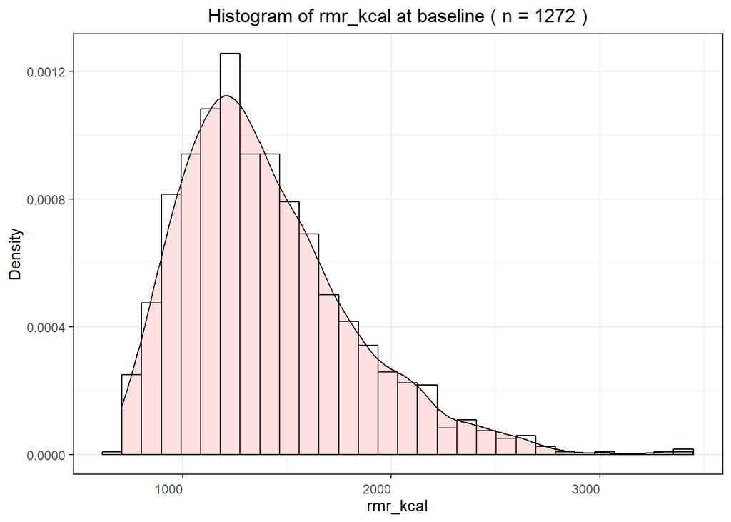

#### Longitudinal plot (from the parsimonious model)

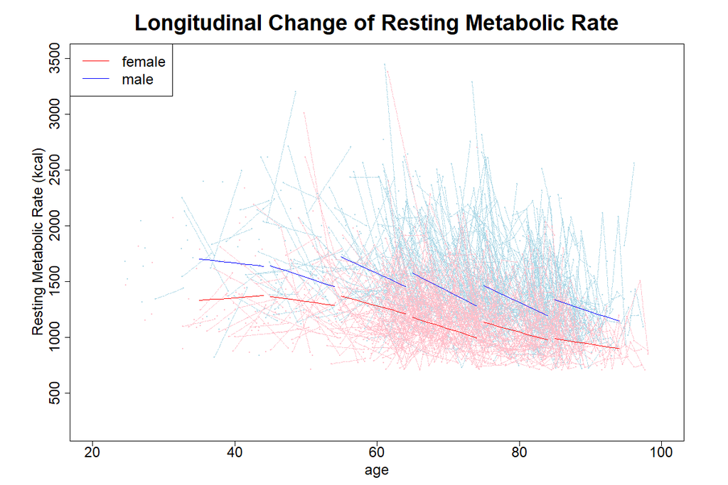

#### Mixed effect model results (from the parsimonious model)

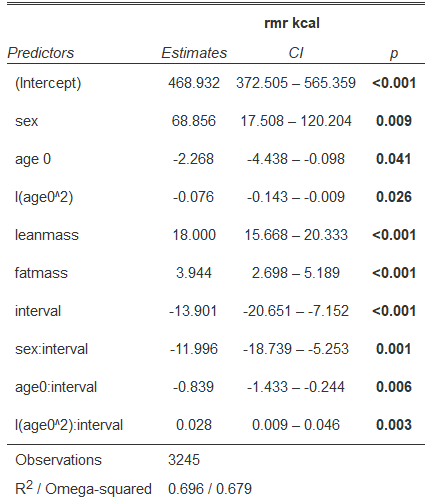

#### Longitudinal plot (from the “base”" model)

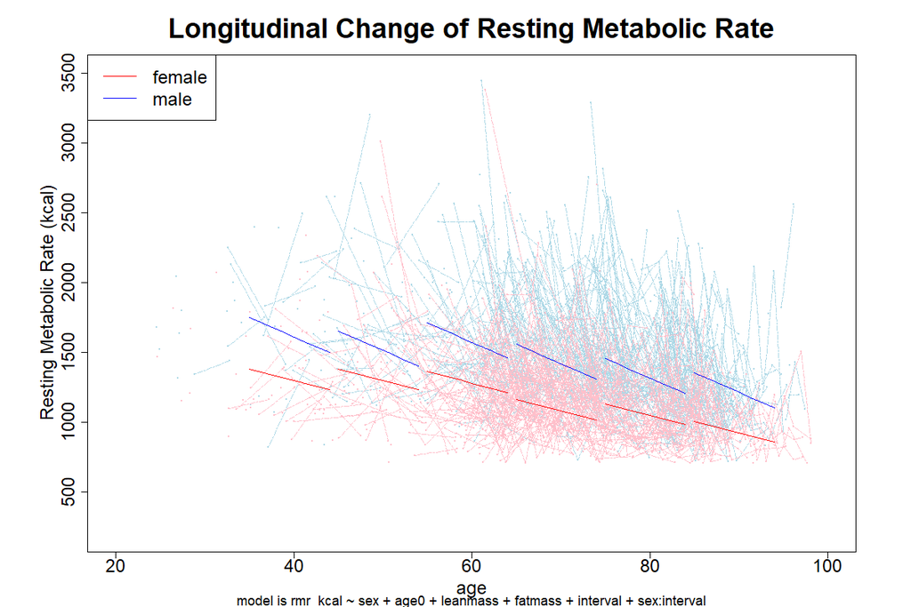

#### Mixed effect model results (from the “base”" model)

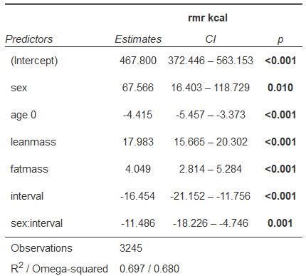

### Cost-capacity ratio

#### Baseline distribution

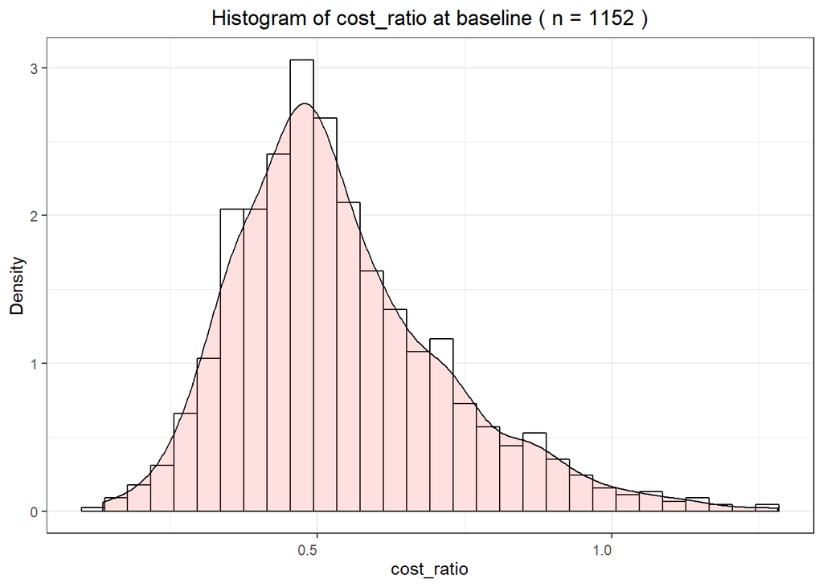

#### Longitudinal plot (from the parsimonious model)

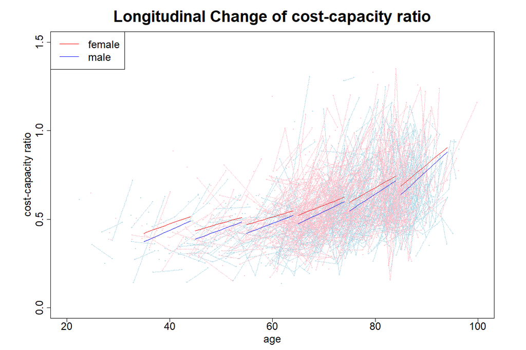

#### Mixed effect model results (from the parsimonious model)

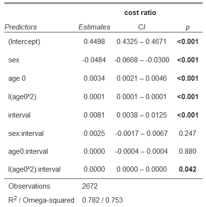

#### Longitudinal plot (from the “base”" model)

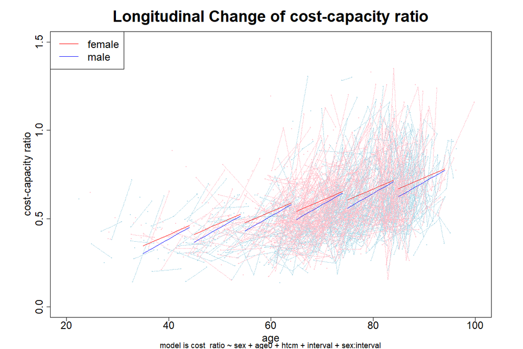

#### Mixed effect model results (from the “base”" model)

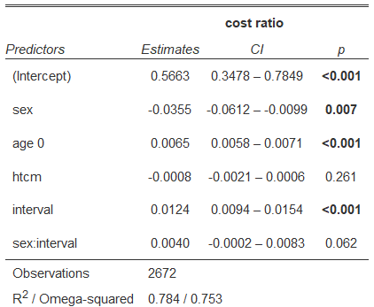

#### Longitudinal plot (from the modified “base”" model)

- I think we need to have the term between time and baseline age (shown as “age0:interval”) since this is testing if older people age faster in this phenotype.

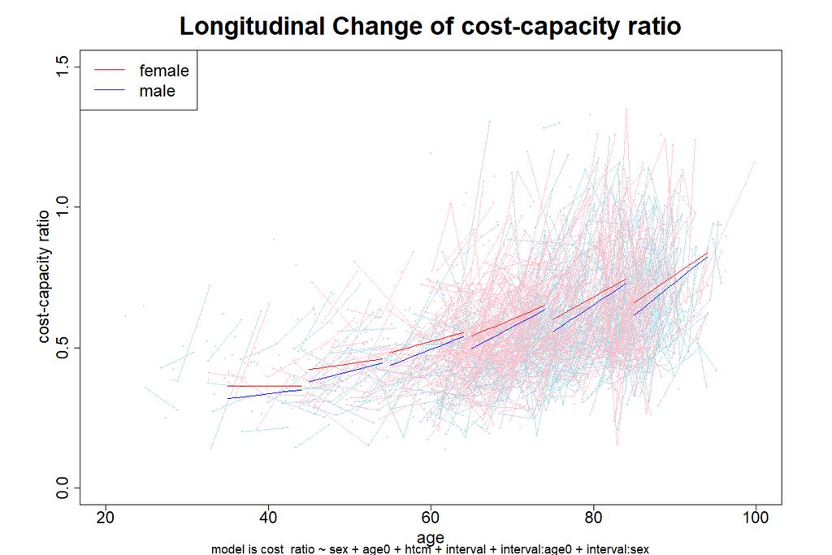

#### Mixed effect model results (from the modeified “base”" model)

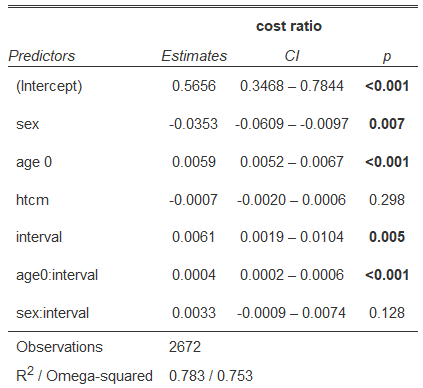

### VO2_max (treadmill)

#### Longitudinal plot (from the parsimonious model)

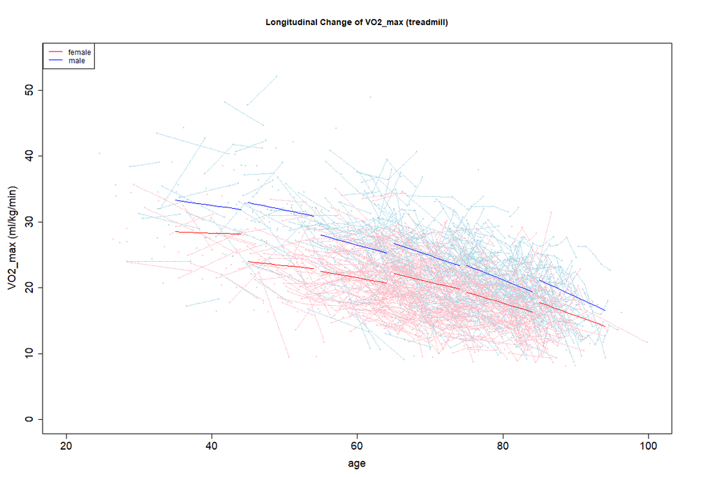

### Peak VO2(during 400m walk)

#### Longitudinal plot (from the parsimonious model)

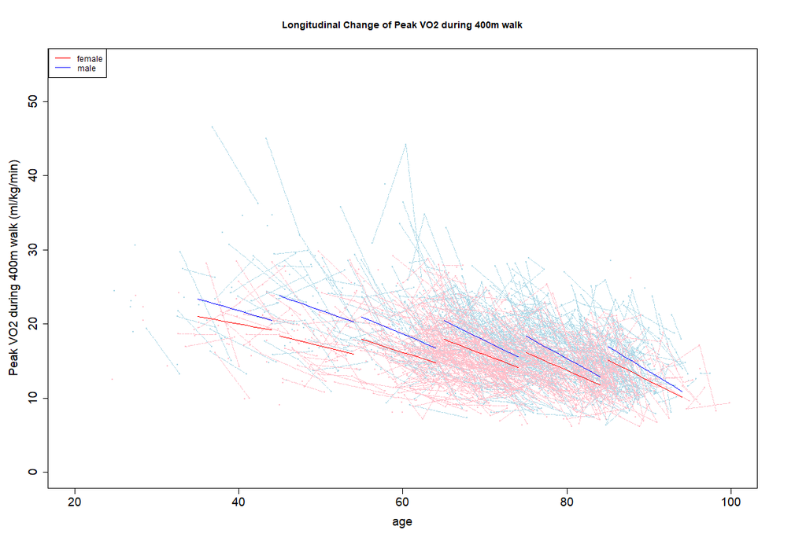

### FEV1

#### Longitudinal plot (from the parsimonious model)

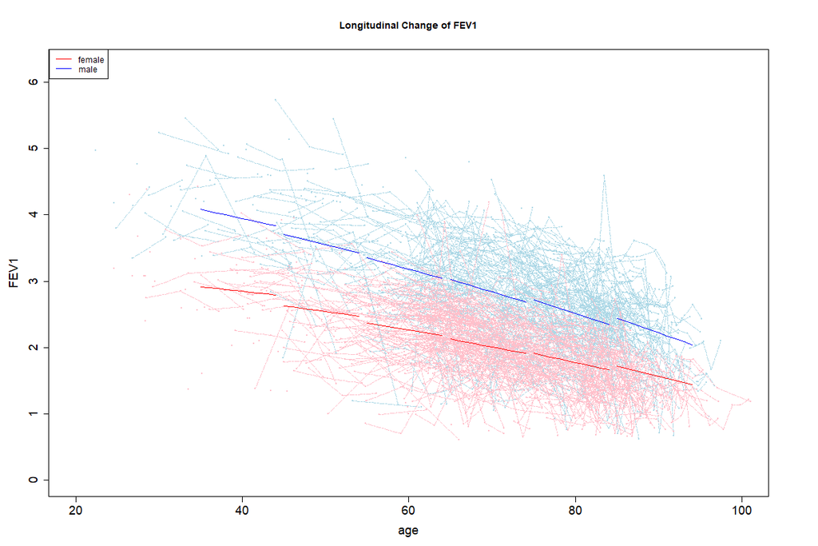

### FVC

#### Longitudinal plot (from the parsimonious model)

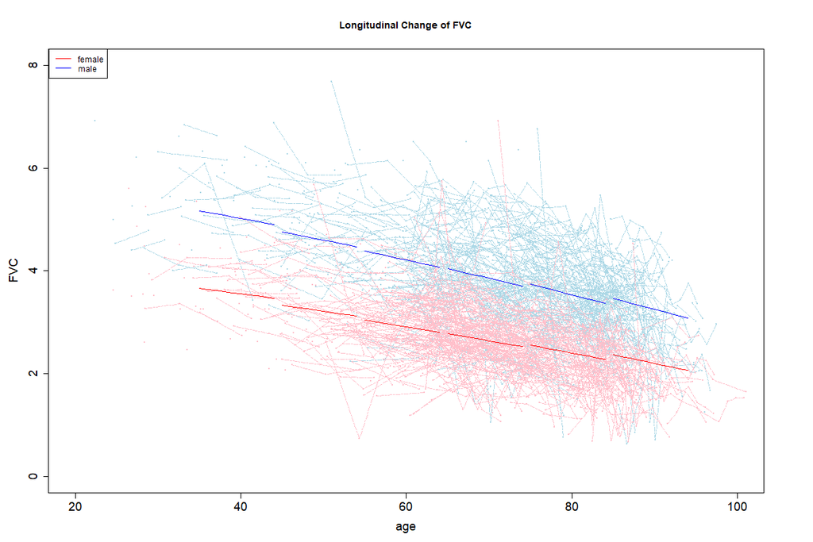